# Risk Factor Analysis

## Outcome Variable

**Outcome Variable:** stunted

## Predictor Variables

**Intervention Variable:** parity

**Adjustment Set:**

- arm
- W_mage
- meducyrs
- feducyrs
- hhwealth_quart
- W_mhtcm
- W_mwtkg
- W_mbmi
- vagbrth
- W_nrooms
- impsan
- delta_W_mage
- delta_meducyrs
- delta_feducyrs
- delta_hhwealth_quart
- delta_W_mhtcm
- delta_W_mwtkg
- delta_W_mbmi
- delta_vagbrth
- delta_W_nrooms
- delta_impsan

## Stratifying Variables

The analysis was stratified on these variable(s):

- agecat
- studyid
- country

## Data Summary

| agecat | studyid | country | parity | stunted | n_cell | n |
| --- | --- | --- | --- | --- | --- | --- |
| Birth | COHORTS | GUATEMALA | 1 | 0 | 103 | 852 |
| Birth | COHORTS | GUATEMALA | 1 | 1 | 9 | 852 |
| Birth | COHORTS | GUATEMALA | 2 | 0 | 124 | 852 |
| Birth | COHORTS | GUATEMALA | 2 | 1 | 13 | 852 |
| Birth | COHORTS | GUATEMALA | 3+ | 0 | 575 | 852 |
| Birth | COHORTS | GUATEMALA | 3+ | 1 | 28 | 852 |
| Birth | COHORTS | INDIA | 1 | 0 | 582 | 4122 |
| Birth | COHORTS | INDIA | 1 | 1 | 114 | 4122 |
| Birth | COHORTS | INDIA | 2 | 0 | 939 | 4122 |
| Birth | COHORTS | INDIA | 2 | 1 | 98 | 4122 |
| Birth | COHORTS | INDIA | 3+ | 0 | 2126 | 4122 |
| Birth | COHORTS | INDIA | 3+ | 1 | 263 | 4122 |
| Birth | COHORTS | PHILIPPINES | 1 | 0 | 629 | 3050 |
| Birth | COHORTS | PHILIPPINES | 1 | 1 | 46 | 3050 |
| Birth | COHORTS | PHILIPPINES | 2 | 0 | 645 | 3050 |
| Birth | COHORTS | PHILIPPINES | 2 | 1 | 42 | 3050 |
| Birth | COHORTS | PHILIPPINES | 3+ | 0 | 1589 | 3050 |
| Birth | COHORTS | PHILIPPINES | 3+ | 1 | 99 | 3050 |
| Birth | GMS-Nepal | NEPAL | 1 | 0 | 158 | 696 |
| Birth | GMS-Nepal | NEPAL | 1 | 1 | 53 | 696 |
| Birth | GMS-Nepal | NEPAL | 2 | 0 | 152 | 696 |
| Birth | GMS-Nepal | NEPAL | 2 | 1 | 28 | 696 |
| Birth | GMS-Nepal | NEPAL | 3+ | 0 | 264 | 696 |
| Birth | GMS-Nepal | NEPAL | 3+ | 1 | 41 | 696 |
| Birth | JiVitA-3 | BANGLADESH | 1 | 0 | 4469 | 22455 |
| Birth | JiVitA-3 | BANGLADESH | 1 | 1 | 2987 | 22455 |
| Birth | JiVitA-3 | BANGLADESH | 2 | 0 | 5323 | 22455 |
| Birth | JiVitA-3 | BANGLADESH | 2 | 1 | 2292 | 22455 |
| Birth | JiVitA-3 | BANGLADESH | 3+ | 0 | 5276 | 22455 |
| Birth | JiVitA-3 | BANGLADESH | 3+ | 1 | 2108 | 22455 |

[output cut: 144 more lines]

The following strata were considered:

- agecat: 24 months, studyid: COHORTS, country: GUATEMALA
- agecat: 24 months, studyid: COHORTS, country: INDIA
- agecat: 24 months, studyid: COHORTS, country: PHILIPPINES
- agecat: 24 months, studyid: GMS-Nepal, country: NEPAL
- agecat: 24 months, studyid: JiVitA-3, country: BANGLADESH
- agecat: 24 months, studyid: Keneba, country: GAMBIA
- agecat: 24 months, studyid: PROVIDE, country: BANGLADESH
- agecat: 24 months, studyid: TanzaniaChild2, country: TANZANIA, UNITED REPUBLIC OF
- agecat: 24 months, studyid: ZVITAMBO, country: ZIMBABWE
- agecat: 6 months, studyid: COHORTS, country: GUATEMALA
- agecat: 6 months, studyid: COHORTS, country: INDIA
- agecat: 6 months, studyid: COHORTS, country: PHILIPPINES
- agecat: 6 months, studyid: GMS-Nepal, country: NEPAL
- agecat: 6 months, studyid: JiVitA-3, country: BANGLADESH
- agecat: 6 months, studyid: Keneba, country: GAMBIA
- agecat: 6 months, studyid: PROVIDE, country: BANGLADESH
- agecat: 6 months, studyid: SAS-CompFeed, country: INDIA
- agecat: 6 months, studyid: SAS-FoodSuppl, country: INDIA
- agecat: 6 months, studyid: TanzaniaChild2, country: TANZANIA, UNITED REPUBLIC OF
- agecat: 6 months, studyid: ZVITAMBO, country: ZIMBABWE
- agecat: Birth, studyid: COHORTS, country: GUATEMALA
- agecat: Birth, studyid: COHORTS, country: INDIA
- agecat: Birth, studyid: COHORTS, country: PHILIPPINES
- agecat: Birth, studyid: GMS-Nepal, country: NEPAL
- agecat: Birth, studyid: JiVitA-3, country: BANGLADESH
- agecat: Birth, studyid: Keneba, country: GAMBIA
- agecat: Birth, studyid: PROVIDE, country: BANGLADESH
- agecat: Birth, studyid: SAS-CompFeed, country: INDIA
- agecat: Birth, studyid: ZVITAMBO, country: ZIMBABWE

### Dropped Strata

Some strata were dropped due to rare outcomes:

- agecat: 6 months, studyid: SAS-FoodSuppl, country: INDIA
- agecat: 24 months, studyid: TanzaniaChild2, country: TANZANIA, UNITED REPUBLIC OF

## Methods Detail

We’re interested in the causal parameters $E[Y_a]$ for all values of $a \in \mathcal{A}$. These parameters represent the mean outcome if, possibly contrary to fact, we intervened to set all units to have $A=a$. Under the randomization and positivity assumptions, these are identified by the statistical parameters $\psi_a=E_W[E_{Y|A,W}(Y|A=a,W)]$. In addition, we’re interested in the mean of $Y$, $E[Y]$ under no intervention (the observed mean). We will estimate these parameters by using SuperLearner to fit the relevant likelihood factors – $E_{Y|A,W}(Y|A=a,W)$ and $p(A=a|W)$, and then updating our likelihood fit using a joint TMLE.

For unadjusted analyses ($W=\{\}$), initial likelihoods were estimated using Lrnr_glm to estimate the simple $E(Y|A)$ and Lrnr_mean to estimate $p(A)$. For adjusted analyses, a small library containing Lrnr_glmnet, Lrnr_xgboost, and Lrnr_mean was used.

Having estimated these parameters, we will then use the delta method to estimate relative risks and attributable risks relative to a prespecified baseline level of $A$.

# Results Detail

## Results Plots

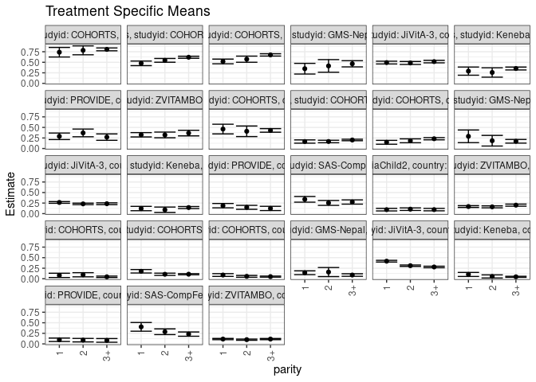

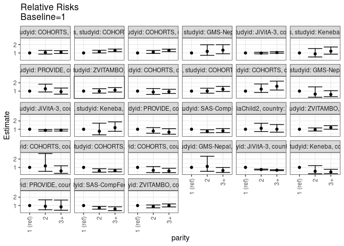

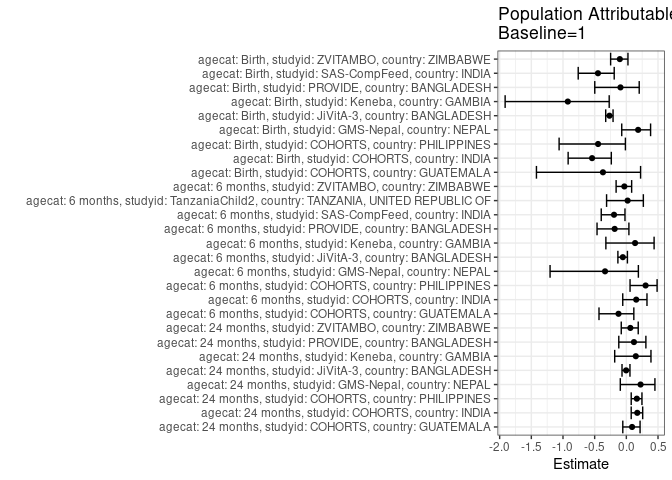

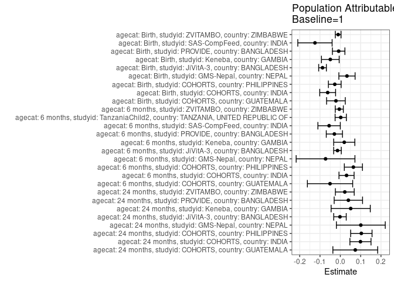

## Results Table

### Parameter: TSM

| agecat | studyid | country | intervention_level | baseline_level | estimate | ci_lower | ci_upper |
| --- | --- | --- | --- | --- | --- | --- | --- |
| Birth | COHORTS | GUATEMALA | 1 | NA | 0.0803571 | 0.0299820 | 0.1307322 |
| Birth | COHORTS | GUATEMALA | 2 | NA | 0.0948905 | 0.0457879 | 0.1439931 |
| Birth | COHORTS | GUATEMALA | 3+ | NA | 0.0464345 | 0.0296294 | 0.0632396 |
| Birth | COHORTS | INDIA | 1 | NA | 0.1775605 | 0.1365678 | 0.2185532 |
| Birth | COHORTS | INDIA | 2 | NA | 0.1062891 | 0.0802738 | 0.1323044 |
| Birth | COHORTS | INDIA | 3+ | NA | 0.1076804 | 0.0936449 | 0.1217159 |
| Birth | COHORTS | PHILIPPINES | 1 | NA | 0.0886727 | 0.0557623 | 0.1215831 |
| Birth | COHORTS | PHILIPPINES | 2 | NA | 0.0573979 | 0.0356517 | 0.0791442 |
| Birth | COHORTS | PHILIPPINES | 3+ | NA | 0.0509225 | 0.0388102 | 0.0630347 |
| Birth | GMS-Nepal | NEPAL | 1 | NA | 0.1426311 | 0.0976723 | 0.1875900 |
| Birth | GMS-Nepal | NEPAL | 2 | NA | 0.1588193 | 0.0515690 | 0.2660696 |
| Birth | GMS-Nepal | NEPAL | 3+ | NA | 0.0884408 | 0.0585368 | 0.1183447 |
| Birth | JiVitA-3 | BANGLADESH | 1 | NA | 0.4166015 | 0.3964704 | 0.4367327 |
| Birth | JiVitA-3 | BANGLADESH | 2 | NA | 0.3095261 | 0.2925665 | 0.3264857 |
| Birth | JiVitA-3 | BANGLADESH | 3+ | NA | 0.2792419 | 0.2614252 | 0.2970587 |
| Birth | Keneba | GAMBIA | 1 | NA | 0.1025641 | 0.0549386 | 0.1501896 |
| Birth | Keneba | GAMBIA | 2 | NA | 0.0547945 | 0.0178664 | 0.0917227 |
| Birth | Keneba | GAMBIA | 3+ | NA | 0.0461538 | 0.0337783 | 0.0585294 |
| Birth | PROVIDE | BANGLADESH | 1 | NA | 0.0973069 | 0.0570663 | 0.1375474 |
| Birth | PROVIDE | BANGLADESH | 2 | NA | 0.0882797 | 0.0472301 | 0.1293293 |
| Birth | PROVIDE | BANGLADESH | 3+ | NA | 0.0825086 | 0.0387454 | 0.1262718 |
| Birth | SAS-CompFeed | INDIA | 1 | NA | 0.4036321 | 0.3005657 | 0.5066985 |
| Birth | SAS-CompFeed | INDIA | 2 | NA | 0.2875537 | 0.2200028 | 0.3551047 |
| Birth | SAS-CompFeed | INDIA | 3+ | NA | 0.2317851 | 0.1812744 | 0.2822959 |
| Birth | ZVITAMBO | ZIMBABWE | 1 | NA | 0.1139911 | 0.0989684 | 0.1290138 |
| Birth | ZVITAMBO | ZIMBABWE | 2 | NA | 0.1004372 | 0.0860408 | 0.1148336 |
| Birth | ZVITAMBO | ZIMBABWE | 3+ | NA | 0.1137611 | 0.1000860 | 0.1274363 |
| 6 months | COHORTS | GUATEMALA | 1 | NA | 0.4606583 | 0.3456967 | 0.5756198 |
| 6 months | COHORTS | GUATEMALA | 2 | NA | 0.4080377 | 0.2830383 | 0.5330370 |
| 6 months | COHORTS | GUATEMALA | 3+ | NA | 0.4287818 | 0.3861215 | 0.4714421 |

[output cut: 51 more lines]

### Parameter: E(Y)

| agecat | studyid | country | intervention_level | baseline_level | estimate | ci_lower | ci_upper |
| --- | --- | --- | --- | --- | --- | --- | --- |
| Birth | COHORTS | GUATEMALA | NA | NA | 0.0586854 | 0.0428942 | 0.0744767 |
| Birth | COHORTS | INDIA | NA | NA | 0.1152353 | 0.1054865 | 0.1249842 |
| Birth | COHORTS | PHILIPPINES | NA | NA | 0.0613115 | 0.0527962 | 0.0698268 |
| Birth | GMS-Nepal | NEPAL | NA | NA | 0.1752874 | 0.1470202 | 0.2035545 |
| Birth | JiVitA-3 | BANGLADESH | NA | NA | 0.3289690 | 0.3216017 | 0.3363364 |
| Birth | Keneba | GAMBIA | NA | NA | 0.0533049 | 0.0415628 | 0.0650470 |
| Birth | PROVIDE | BANGLADESH | NA | NA | 0.0890538 | 0.0649864 | 0.1131212 |
| Birth | SAS-CompFeed | INDIA | NA | NA | 0.2787540 | 0.2475949 | 0.3099131 |
| Birth | ZVITAMBO | ZIMBABWE | NA | NA | 0.1033588 | 0.0982930 | 0.1084246 |
| 6 months | COHORTS | GUATEMALA | NA | NA | 0.4099896 | 0.3788775 | 0.4411017 |
| 6 months | COHORTS | INDIA | NA | NA | 0.1957586 | 0.1838852 | 0.2076319 |
| 6 months | COHORTS | PHILIPPINES | NA | NA | 0.2112260 | 0.1958496 | 0.2266024 |
| 6 months | GMS-Nepal | NEPAL | NA | NA | 0.2163121 | 0.1823021 | 0.2503220 |
| 6 months | JiVitA-3 | BANGLADESH | NA | NA | 0.2513830 | 0.2432594 | 0.2595066 |
| 6 months | Keneba | GAMBIA | NA | NA | 0.1398644 | 0.1229849 | 0.1567440 |
| 6 months | PROVIDE | BANGLADESH | NA | NA | 0.1589404 | 0.1297581 | 0.1881227 |
| 6 months | SAS-CompFeed | INDIA | NA | NA | 0.2844311 | 0.2666491 | 0.3022132 |
| 6 months | TanzaniaChild2 | TANZANIA, UNITED REPUBLIC OF | NA | NA | 0.0967419 | 0.0837671 | 0.1097166 |
| 6 months | ZVITAMBO | ZIMBABWE | NA | NA | 0.1628980 | 0.1551237 | 0.1706723 |
| 24 months | COHORTS | GUATEMALA | NA | NA | 0.8120301 | 0.7885439 | 0.8355162 |
| 24 months | COHORTS | INDIA | NA | NA | 0.5742604 | 0.5575886 | 0.5909321 |
| 24 months | COHORTS | PHILIPPINES | NA | NA | 0.6229039 | 0.6036892 | 0.6421186 |
| 24 months | GMS-Nepal | NEPAL | NA | NA | 0.4487705 | 0.4045970 | 0.4929440 |
| 24 months | JiVitA-3 | BANGLADESH | NA | NA | 0.4910797 | 0.4779658 | 0.5041936 |
| 24 months | Keneba | GAMBIA | NA | NA | 0.3415698 | 0.3165034 | 0.3666361 |
| 24 months | PROVIDE | BANGLADESH | NA | NA | 0.3287197 | 0.2903909 | 0.3670485 |
| 24 months | ZVITAMBO | ZIMBABWE | NA | NA | 0.3471629 | 0.3241082 | 0.3702176 |

### Parameter: RR

| agecat | studyid | country | intervention_level | baseline_level | estimate | ci_lower | ci_upper |
| --- | --- | --- | --- | --- | --- | --- | --- |
| Birth | COHORTS | GUATEMALA | 1 | 1 | 1.0000000 | 1.0000000 | 1.0000000 |
| Birth | COHORTS | GUATEMALA | 2 | 1 | 1.1808597 | 0.5238079 | 2.6621012 |
| Birth | COHORTS | GUATEMALA | 3+ | 1 | 0.5778515 | 0.2801877 | 1.1917453 |
| Birth | COHORTS | INDIA | 1 | 1 | 1.0000000 | 1.0000000 | 1.0000000 |
| Birth | COHORTS | INDIA | 2 | 1 | 0.5986078 | 0.4277360 | 0.8377396 |
| Birth | COHORTS | INDIA | 3+ | 1 | 0.6064434 | 0.4653614 | 0.7902969 |
| Birth | COHORTS | PHILIPPINES | 1 | 1 | 1.0000000 | 1.0000000 | 1.0000000 |
| Birth | COHORTS | PHILIPPINES | 2 | 1 | 0.6473011 | 0.3811156 | 1.0994005 |
| Birth | COHORTS | PHILIPPINES | 3+ | 1 | 0.5742743 | 0.3699340 | 0.8914860 |
| Birth | GMS-Nepal | NEPAL | 1 | 1 | 1.0000000 | 1.0000000 | 1.0000000 |
| Birth | GMS-Nepal | NEPAL | 2 | 1 | 1.1134967 | 0.5307744 | 2.3359737 |
| Birth | GMS-Nepal | NEPAL | 3+ | 1 | 0.6200664 | 0.3883874 | 0.9899452 |
| Birth | JiVitA-3 | BANGLADESH | 1 | 1 | 1.0000000 | 1.0000000 | 1.0000000 |
| Birth | JiVitA-3 | BANGLADESH | 2 | 1 | 0.7429788 | 0.6913054 | 0.7985147 |
| Birth | JiVitA-3 | BANGLADESH | 3+ | 1 | 0.6702854 | 0.6202678 | 0.7243363 |
| Birth | Keneba | GAMBIA | 1 | 1 | 1.0000000 | 1.0000000 | 1.0000000 |
| Birth | Keneba | GAMBIA | 2 | 1 | 0.5342466 | 0.2356709 | 1.2110933 |
| Birth | Keneba | GAMBIA | 3+ | 1 | 0.4500000 | 0.2632335 | 0.7692790 |
| Birth | PROVIDE | BANGLADESH | 1 | 1 | 1.0000000 | 1.0000000 | 1.0000000 |
| Birth | PROVIDE | BANGLADESH | 2 | 1 | 0.9072299 | 0.4881820 | 1.6859819 |
| Birth | PROVIDE | BANGLADESH | 3+ | 1 | 0.8479215 | 0.4337487 | 1.6575748 |
| Birth | SAS-CompFeed | INDIA | 1 | 1 | 1.0000000 | 1.0000000 | 1.0000000 |
| Birth | SAS-CompFeed | INDIA | 2 | 1 | 0.7124155 | 0.5683918 | 0.8929329 |
| Birth | SAS-CompFeed | INDIA | 3+ | 1 | 0.5742485 | 0.3882245 | 0.8494090 |
| Birth | ZVITAMBO | ZIMBABWE | 1 | 1 | 1.0000000 | 1.0000000 | 1.0000000 |
| Birth | ZVITAMBO | ZIMBABWE | 2 | 1 | 0.8810970 | 0.7252814 | 1.0703871 |
| Birth | ZVITAMBO | ZIMBABWE | 3+ | 1 | 0.9979827 | 0.8349789 | 1.1928078 |
| 6 months | COHORTS | GUATEMALA | 1 | 1 | 1.0000000 | 1.0000000 | 1.0000000 |
| 6 months | COHORTS | GUATEMALA | 2 | 1 | 0.8857709 | 0.5978709 | 1.3123068 |
| 6 months | COHORTS | GUATEMALA | 3+ | 1 | 0.9308024 | 0.7124929 | 1.2160023 |

[output cut: 51 more lines]

### Parameter: PAR

| agecat | studyid | country | intervention_level | baseline_level | estimate | ci_lower | ci_upper |
| --- | --- | --- | --- | --- | --- | --- | --- |
| Birth | COHORTS | GUATEMALA | 1 | NA | -0.0216717 | -0.0677134 | 0.0243700 |
| Birth | COHORTS | INDIA | 1 | NA | -0.0623252 | -0.1013511 | -0.0232993 |
| Birth | COHORTS | PHILIPPINES | 1 | NA | -0.0273612 | -0.0587417 | 0.0040192 |
| Birth | GMS-Nepal | NEPAL | 1 | NA | 0.0326562 | -0.0072937 | 0.0726062 |
| Birth | JiVitA-3 | BANGLADESH | 1 | NA | -0.0876325 | -0.1065680 | -0.0686970 |
| Birth | Keneba | GAMBIA | 1 | NA | -0.0492592 | -0.0928837 | -0.0056347 |
| Birth | PROVIDE | BANGLADESH | 1 | NA | -0.0082531 | -0.0390474 | 0.0225412 |
| Birth | SAS-CompFeed | INDIA | 1 | NA | -0.1248781 | -0.2093168 | -0.0404395 |
| Birth | ZVITAMBO | ZIMBABWE | 1 | NA | -0.0106323 | -0.0247282 | 0.0034636 |
| 6 months | COHORTS | GUATEMALA | 1 | NA | -0.0506687 | -0.1621118 | 0.0607745 |
| 6 months | COHORTS | INDIA | 1 | NA | 0.0305149 | -0.0066779 | 0.0677078 |
| 6 months | COHORTS | PHILIPPINES | 1 | NA | 0.0642295 | 0.0196598 | 0.1087991 |
| 6 months | GMS-Nepal | NEPAL | 1 | NA | -0.0727294 | -0.2173467 | 0.0718880 |
| 6 months | JiVitA-3 | BANGLADESH | 1 | NA | -0.0139630 | -0.0328223 | 0.0048963 |
| 6 months | Keneba | GAMBIA | 1 | NA | 0.0192804 | -0.0327611 | 0.0713218 |
| 6 months | PROVIDE | BANGLADESH | 1 | NA | -0.0293517 | -0.0691827 | 0.0104794 |
| 6 months | SAS-CompFeed | INDIA | 1 | NA | -0.0552619 | -0.1104057 | -0.0001182 |
| 6 months | TanzaniaChild2 | TANZANIA, UNITED REPUBLIC OF | 1 | NA | 0.0019678 | -0.0257211 | 0.0296567 |
| 6 months | ZVITAMBO | ZIMBABWE | 1 | NA | -0.0051513 | -0.0250773 | 0.0147746 |
| 24 months | COHORTS | GUATEMALA | 1 | NA | 0.0735477 | -0.0367311 | 0.1838266 |
| 24 months | COHORTS | INDIA | 1 | NA | 0.0990241 | 0.0470821 | 0.1509661 |
| 24 months | COHORTS | PHILIPPINES | 1 | NA | 0.1034003 | 0.0507407 | 0.1560599 |
| 24 months | GMS-Nepal | NEPAL | 1 | NA | 0.1008220 | -0.0194282 | 0.2210723 |
| 24 months | JiVitA-3 | BANGLADESH | 1 | NA | -0.0017709 | -0.0325635 | 0.0290217 |
| 24 months | Keneba | GAMBIA | 1 | NA | 0.0510176 | -0.0453140 | 0.1473492 |
| 24 months | PROVIDE | BANGLADESH | 1 | NA | 0.0395308 | -0.0303052 | 0.1093668 |
| 24 months | ZVITAMBO | ZIMBABWE | 1 | NA | 0.0219492 | -0.0244189 | 0.0683173 |

### Parameter: PAF

| agecat | studyid | country | intervention_level | baseline_level | estimate | ci_lower | ci_upper |
| --- | --- | --- | --- | --- | --- | --- | --- |
| Birth | COHORTS | GUATEMALA | 1 | NA | -0.3692857 | -1.4191803 | 0.2249675 |
| Birth | COHORTS | INDIA | 1 | NA | -0.5408514 | -0.9187948 | -0.2373511 |
| Birth | COHORTS | PHILIPPINES | 1 | NA | -0.4462659 | -1.0614244 | -0.0146795 |
| Birth | GMS-Nepal | NEPAL | 1 | NA | 0.1863012 | -0.0727521 | 0.3827970 |
| Birth | JiVitA-3 | BANGLADESH | 1 | NA | -0.2663852 | -0.3257644 | -0.2096656 |
| Birth | Keneba | GAMBIA | 1 | NA | -0.9241026 | -1.9135260 | -0.2706839 |
| Birth | PROVIDE | BANGLADESH | 1 | NA | -0.0926752 | -0.4985608 | 0.2032761 |
| Birth | SAS-CompFeed | INDIA | 1 | NA | -0.4479868 | -0.7597533 | -0.1914544 |
| Birth | ZVITAMBO | ZIMBABWE | 1 | NA | -0.1028678 | -0.2480898 | 0.0254568 |
| 6 months | COHORTS | GUATEMALA | 1 | NA | -0.1235852 | -0.4316052 | 0.1181620 |
| 6 months | COHORTS | INDIA | 1 | NA | 0.1558805 | -0.0568648 | 0.3258005 |
| 6 months | COHORTS | PHILIPPINES | 1 | NA | 0.3040793 | 0.0586051 | 0.4855446 |
| 6 months | GMS-Nepal | NEPAL | 1 | NA | -0.3362243 | -1.2041598 | 0.1899429 |
| 6 months | JiVitA-3 | BANGLADESH | 1 | NA | -0.0555446 | -0.1333772 | 0.0169430 |
| 6 months | Keneba | GAMBIA | 1 | NA | 0.1378503 | -0.3231498 | 0.4382328 |
| 6 months | PROVIDE | BANGLADESH | 1 | NA | -0.1846710 | -0.4626413 | 0.0404719 |
| 6 months | SAS-CompFeed | INDIA | 1 | NA | -0.1942893 | -0.3961861 | -0.0215880 |
| 6 months | TanzaniaChild2 | TANZANIA, UNITED REPUBLIC OF | 1 | NA | 0.0203404 | -0.3120177 | 0.2685061 |
| 6 months | ZVITAMBO | ZIMBABWE | 1 | NA | -0.0316230 | -0.1615244 | 0.0837507 |
| 24 months | COHORTS | GUATEMALA | 1 | NA | 0.0905727 | -0.0560188 | 0.2168150 |
| 24 months | COHORTS | INDIA | 1 | NA | 0.1724377 | 0.0767456 | 0.2582117 |
| 24 months | COHORTS | PHILIPPINES | 1 | NA | 0.1659972 | 0.0769338 | 0.2464671 |
| 24 months | GMS-Nepal | NEPAL | 1 | NA | 0.2246628 | -0.0952940 | 0.4511540 |
| 24 months | JiVitA-3 | BANGLADESH | 1 | NA | -0.0036062 | -0.0683189 | 0.0571866 |
| 24 months | Keneba | GAMBIA | 1 | NA | 0.1493622 | -0.1837922 | 0.3887570 |
| 24 months | PROVIDE | BANGLADESH | 1 | NA | 0.1202568 | -0.1192241 | 0.3084958 |
| 24 months | ZVITAMBO | ZIMBABWE | 1 | NA | 0.0632244 | -0.0802525 | 0.1876450 |